# Data_Analyst_ND_Project1_t

**Stroop task**

In a Stroop task, participants are presented with a list of words, with each word displayed in a color of ink. The participant’s task is to say out loud the color of the ink in which the word is printed. The task has two conditions: a congruent words condition, and an incongruent words condition. In the congruent words condition, the words being displayed are color words whose names match the colors in which they are printed: for example RED, BLUE. In the incongruent words condition, the words displayed are color words whose names do not match the colors in which they are printed: for example PURPLE, ORANGE. In each case, we measure the time it takes to name the ink colors in equally-sized lists. Each participant will go through and record a time from each condition.

#### 1. What is the independent variable and dependent variable in the test?

**Dependent** – time that each person was spending on each list of words.

**Independent** – participants in reading words in conditions (congruent /incongruent)

#### 2. What is an appropriate set of hypotheses for this task? What kind of statistical test to perform?

H0: The differentce beiween congruent test's reading time and incongruent is small. (μ congruent - μ incongruent = μ difference where μ difference can be equals to 0)

Ha: The differentce beiween congruent test's reading time and incongruent is significant. (μ congruent ≠ μ incongruent)

A μincongruent we would use as the population mean for the incongruent task and μcongruent - the population mean for the congruent task.

Statistical testing with the dependent t-test for paired samples because there are two samples are paired: one participent has done both tests, so it is our paired element of “Stoop task” test. Moreover, t-test has been choosen because the given data is a sapmle of population with less than 30 participants in count and without standard deviation for population that can be estimated from sapmle - z-test canbe performed.

#### 3. Repost some descriptive statistics regarding this data set with al least one measure of tendency and one of variability.

learning more about our data by looking into it.

```python
# do preparations for working with given sample of data by importing libraries
%matplotlib inline
import pandas as pd
import numpy as np
import seaborn as sns
import scipy.stats as s
```

```python
path = r'~/Downloads/stroopdata_2.csv'
data = pd.read_csv(path)
# callculate the difference between Incongruent and Congruent reading times - Delta
data['Delta'] = data['Incongruent'] - data['Congruent']
# get some caclucations of data that we need
data.describe()
```

|  | Congruent | Incongruent | Delta |
| --- | --- | --- | --- |
| count | 24.000000 | 24.000000 | 24.000000 |
| mean | 14.051125 | 22.015917 | 7.964792 |
| std | 3.559358 | 4.797057 | 4.864827 |
| min | 8.630000 | 15.687000 | 1.950000 |
| 25% | 11.895250 | 18.716750 | 3.645500 |
| 50% | 14.356500 | 21.017500 | 7.666500 |
| 75% | 16.200750 | 24.051500 | 10.258500 |
| max | 22.328000 | 35.255000 | 21.919000 |

#### 4. Provide visualization that shows distribution of sample data. Give your observation results.

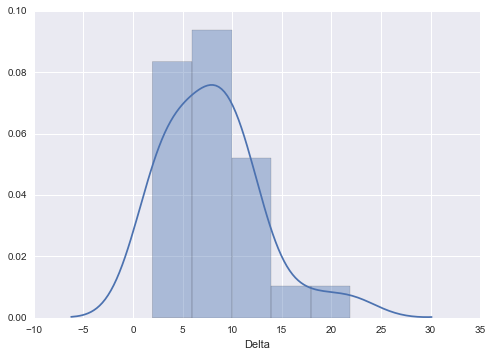

```python
sns.distplot(data['Delta'])
```

Detla destribution is mostly mormal; however if we look at Incongruent and Congruent, we see that Incongruent is adding this tail from 15 to 20.

Overlapping between Incongruent and Congruent:

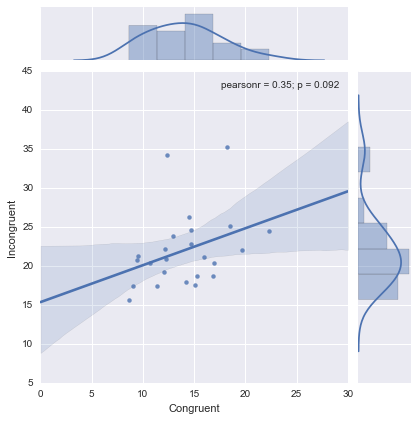

```python
sns.jointplot("Congruent", "Incongruent", data, kind='reg');
```

##### Over all, the destribution of data is more or less even (normal) based on Delta histogram plot and Pairplots of Congruent vs Incongruent.

#### 5. Perform the statistical test and report the result.

Confident level – 95%

```python
tt = 7.96/(4.86/np.sqrt(24)) # calculate t = x̄delta/(s/sqrt(n)
tt
```

```
8.0238429434378986
```

```python
data['Delta'].count()-1 # find degree of freedom n - 1 for diffrence
```

```
23
```

```python
s.t.sf(np.abs(tt), 23)*2 # calculate p value
```

```
4.0755364745654717e-08
```

```python
s.t.ppf(.95, 23) # calculate t-critical value with CI and DF
```

```
1.7138715277470473
```

**Reject of the null hypothesis</b> – the null hypothesis can be rejected based on that t statistical value > t critical value.**

**Conclusion based on experimental task** – We see that the difference between reading time matching color and word list is much faster (Congruent) than Incongruent. By saying that, our alternative hyposesis is true.

**Matching result with your expectations – By looking at the given data it was obvious that there is the difference betwenn 2 lists, the result conclude that this difference bigger thwn it seems. Reading matching word/color list is easier.**